# Day 4: Tidying Data

Brennan & Matt

2023-06-15

## Loading Data ———–

```r
climate_data <- readRDS("../data/clean_climate_data.rds")
```

Matt cleaned this data extensively, and thoroughly explained his thought process, in `15_wrangle.rmd`. It might be helpful for you to look at later if you want to see how data wrangling is done from start to end. Take a gander, if you dare!

## Looking at climate_data ———–

```r
View(climate_data)
```

We can see that there is a set of related columns, `outreach` to `mentoring`, which could be plotted together. Those columns reflect how much the respondents felt they did of each activity.

Maybe we’re interested in whether deaf or hearing faculty had different experiences of the activities.

Let’s focus on these variables and remove rows with no information about if they were deaf or hearing.

```r
climate_data <- climate_data %>%
  select(hearing_status,
         academic_rank,
         outreach:mentoring) %>%
  filter(!is.na(hearing_status))
```

If we wanted to plot these activites together, we would need to tidy the data. We could put the variable names in a column called `activity`. We could put the values in a column called `amount`.

## Tidying climate_data ———–

```r
# Tidy the climate data
climate_tidy <- pivot_longer(
  data = climate_data,
  cols = outreach:mentoring,
  names_to = "activity",
  values_to = "amount"
)
```

Try reading the code above. Note that you don’t need “data =”, “cols =”, “names_to =”, or “values_to =”, but they make it clearer for the reader. Do you understand what the function does with this dataset?

The data is now tidy and can be visualized!

## Visualizing this data ———–

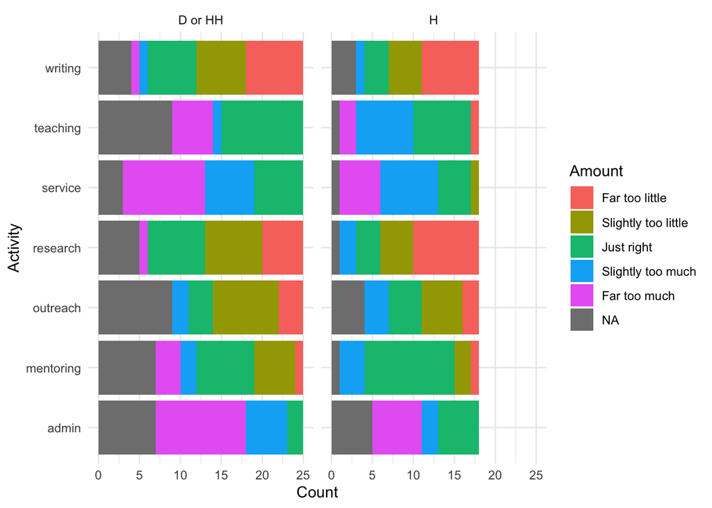

```r
# Load required libraries
library(dplyr)
library(ggplot2)

# Create a summary table
summary_table <- climate_tidy %>%
  group_by(hearing_status, activity, amount) %>%
  summarise(count = n(), .groups = "drop")

# Create the plot
ggplot(data = summary_table, mapping = aes(x = activity, y = count, fill = amount)) +
  geom_bar(stat = "identity", position = "stack") +
  facet_wrap(~hearing_status) +
  ylab("Count") +
  xlab("Activity") +
  labs(fill = "Amount") +
  theme_minimal() +
  coord_flip()
```

Try reading the code above and guessing what each function does.

Or try making your own visualizations from the data, if you don’t want to go home!